# Topic modeling with R

Somnath Mukherjee

June 12, 2019

## Topic Modeling with LDA

Topic modeling is an unsupervised machine learning technique to automatically identify topics present in a text object and to derive hidden patterns exhibited by a text corpus. In topic modeling, documents are not assumed to belong to one topic or category, but simultaneously belong to several topics.

The workhorse function for the topic model is LDA, which stands for Latent Dirichlet Allocation.

### Install and Load Required Packages

```r
ipak <- function(pkg){
    new.pkg <- pkg[!(pkg %in% installed.packages()[, "Package"])]
    if (length(new.pkg))
        install.packages(new.pkg, dependencies = TRUE)
    sapply(pkg, require, character.only = TRUE)
}

# usage
packages <- c("knitr", "kableExtra", "tidyverse","psych", "PerformanceAnalytics",
              "topicmodels", "corrplot","SentimentAnalysis","tm","quanteda",
              "wordcloud")
ipak(packages)
```

```
##                knitr           kableExtra            tidyverse
##                 TRUE                 TRUE                 TRUE
##                psych PerformanceAnalytics          topicmodels
##                 TRUE                 TRUE                 TRUE
##             corrplot    SentimentAnalysis                   tm
##                 TRUE                 TRUE                 TRUE
##             quanteda            wordcloud
##                 TRUE                 TRUE
```

### Data description

We will now use a dataset that contains the lead paragraph of around 5,000 articles about the economy published in the New York Times between 1980 and 2014. As before, we will preprocess the text using the standard set of techniques.

The number of topics in a topic model is somewhat arbitrary, so you need to play with the number of topics to see if you get anything more meaningful. We start here with 30 topics.

```r
nyt <- read.csv("nytimes.csv", stringsAsFactors = FALSE)
nytcorpus <- corpus(nyt$lead_paragraph)
nytdfm <- dfm(nytcorpus, remove=stopwords("english"), verbose=TRUE,
               remove_punct=TRUE, remove_numbers=TRUE)
cdfm <- dfm_trim(nytdfm, min_docfreq = 2)

# estimate LDA with K topics
K <- 30
lda <- LDA(cdfm, k = K, method = "Gibbs",
                control = list(verbose=25L, seed = 123, burnin = 100, iter = 500))
```

```
## K = 30; V = 11112; M = 5000
## Sampling 600 iterations!
## Iteration 25 ...
## Iteration 50 ...
## Iteration 75 ...
## Iteration 100 ...
## Iteration 125 ...
## Iteration 150 ...
## Iteration 175 ...
## Iteration 200 ...
## Iteration 225 ...
## Iteration 250 ...
## Iteration 275 ...
## Iteration 300 ...
## Iteration 325 ...
## Iteration 350 ...
## Iteration 375 ...
## Iteration 400 ...
## Iteration 425 ...
## Iteration 450 ...
## Iteration 475 ...
## Iteration 500 ...
## Iteration 525 ...
## Iteration 550 ...
## Iteration 575 ...
## Iteration 600 ...
## Gibbs sampling completed!
```

We can use get_terms to the top n terms from the topic model, and get_topics to predict the top k topic for each document. This will help us interpret the results of the model.

```r
terms <- get_terms(lda, 10)
terms[,1]
```

```
##  [1] "economic"   "growth"     "economy"    "said"       "recovery"
##  [6] "strong"     "economists" "signs"      "today"      "economist"
```

```r
topics <- get_topics(lda, 1)
head(topics)
```

```
## text1 text2 text3 text4 text5 text6
##    22    20    29    12    21    28
```

List top 10 terms under each topic.

```r
data.frame(terms(lda, 10))
```

```
##       Topic.1       Topic.2   Topic.3 Topic.4 Topic.5 Topic.6 Topic.7
## 1    economic         level   federal     one     can     now    last
## 2      growth        report   reserve    like     get    even    year
## 3     economy         index       fed    even    just    much   first
## 4        said         month  chairman    make  people     say  months
## 5    recovery         since    policy     day   going    come   years
## 6      strong     yesterday committee without america     yet   three
## 7  economists          said   meeting  little      us    just     two
## 8       signs     according greenspan    line     way  future    time
## 9       today manufacturing     today  around   right  likely   since
## 10  economist    confidence    market    part  things  become    half
##      Topic.8   Topic.9   Topic.10   Topic.11    Topic.12 Topic.13
## 1      money    prices   economic    economy        said        s
## 2    billion inflation     editor  recession     million      one
## 3      banks     price     policy economists        last      war
```

[output cut: 40 more lines]

Let’s take a closer look at some of these topics. To help us interpret the output, we can look at the words associated with each topic and take a random sample of documents highly associated with each topic.

```r
# Topic 11
paste(terms[,11], collapse=", ")
```

```
## [1] "economy, recession, economists, many, may, recent, growing, recovery, end, still"
```

```r
sample(nyt$lead_paragraph[topics==11], 1)
```

```
## [1] "During the presidential campaign, Al Gore portrayed George W. Bush's tax-cut proposal as way out on the fiscal fringe, a risky scheme that would send the healthy economy into a downward spiral. Even Republicans saw his tax plan more as a wish list than a program that could be enacted. Now, w…
```

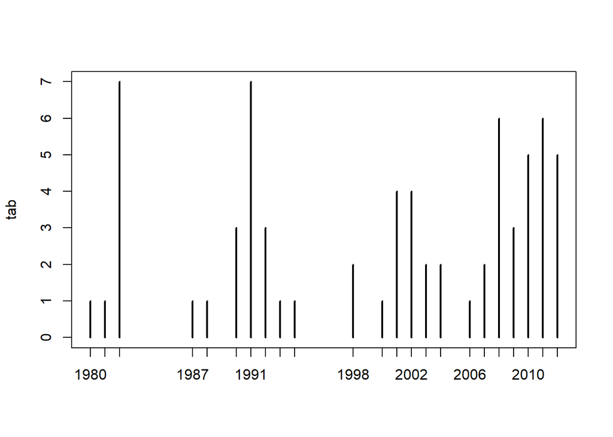

```r
# add predicted topic to dataset
nyt$pred_topic <- topics
nyt$year <- substr(nyt$datetime, 1, 4) # extract year
# frequency table with articles about recession market, per year
tab <- table(nyt$year[nyt$pred_topic==11])
plot(tab)
```

LDA is a probabilistic model, which means that for each document, it actually computes a distribution over topics. In other words, each document is considered to be about a mixture of topics.  
This information is included in the matrix gamma in the LDA object.

```r
# Topic 11
paste(terms[,11], collapse=", ")
```

```
## [1] "economy, recession, economists, many, may, recent, growing, recovery, end, still"
```

So we can actually take the information in the matrix and aggregate it to compute the average probability that an article each year is about a particular topic. Let’s now choose Topic 11, which appears to be related to the economic recession.

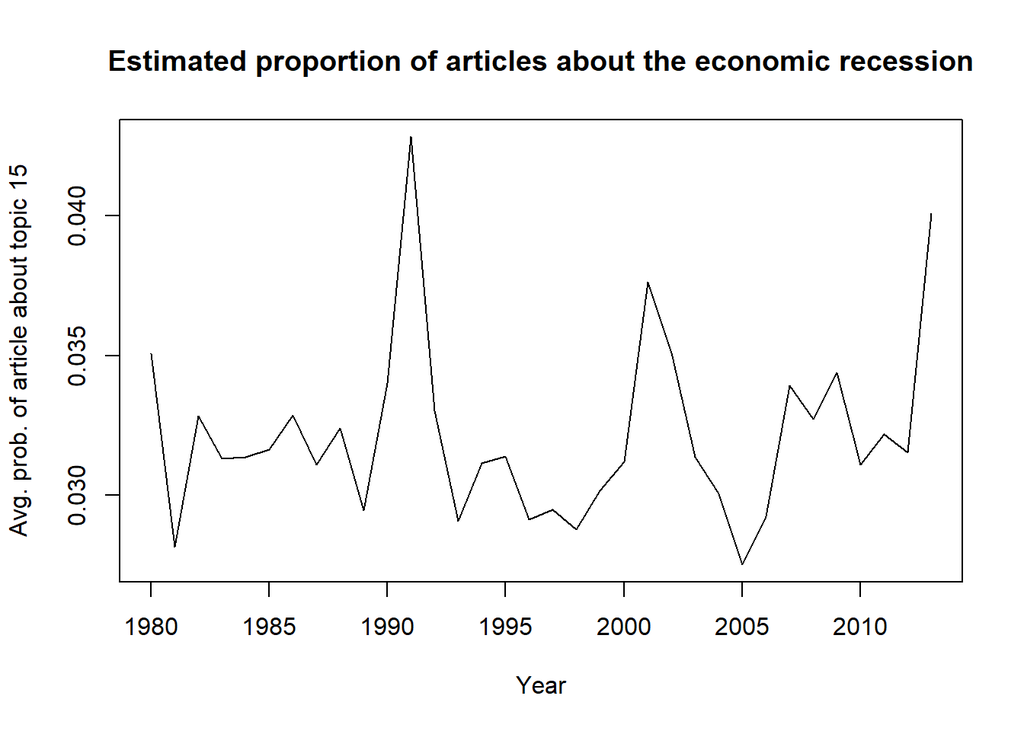

```r
# add probability to df
nyt$prob_topic <- lda@gamma[,11]
# now aggregate at the year level
agg <- aggregate(nyt$prob_topic, by=list(year=nyt$year), FUN=mean)
# and plot it
plot(agg$year, agg$x, type="l", xlab="Year", ylab="Avg. prob. of article about topic 15",
     main="Estimated proportion of articles about the economic recession")
```

```r
topic <- 11
df <- data.frame(term = lda@terms, p = exp(lda@beta[topic,]))
head(df[order(-df$p),])
```

```
##           term          p
## 184    economy 0.12020333
## 649  recession 0.06913920
## 900 economists 0.02930687
## 357       many 0.02849633
## 732        may 0.02780158
## 149     recent 0.02050670
```

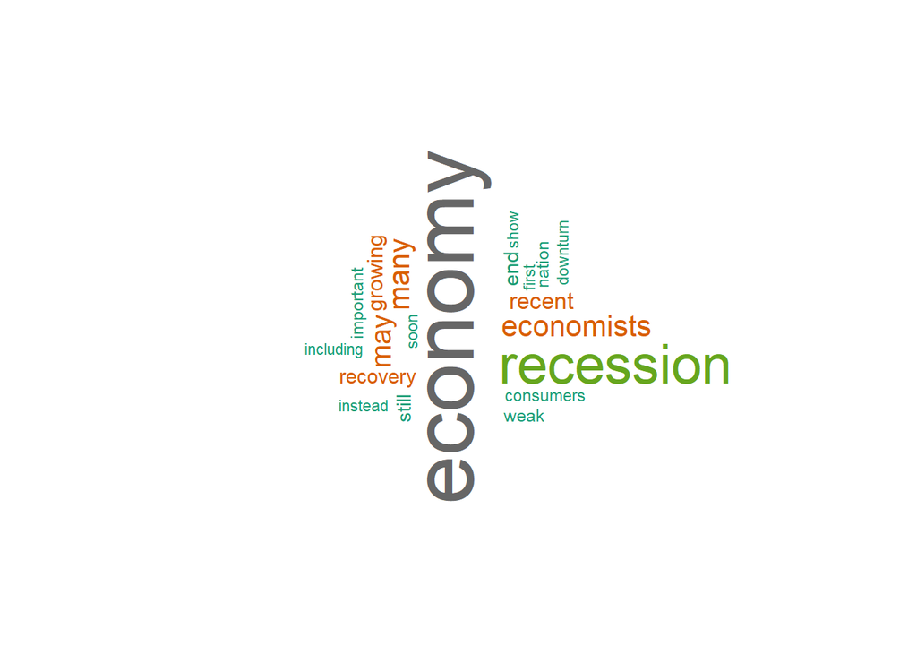

```r
wordcloud(words = df$term,
          freq = df$p,
          max.words = 20,
          random.order = FALSE,
          rot.per = 0.35,
          colors=brewer.pal(8, "Dark2"))
```